# Distribute

`distribute()` shares according with a number of parameters a given amount of energy or power among consumers.

Basic parameters:

- `flow`: Energy or power to be exchanged with the energy storage (negative means discharge)
- `soc`: Current state of charge.
- `vol`: Objective state of charge to be achieved.

The return is a list:

- `soc`: Updated state of charge of the energy storage
- `flow`: Energy or power flow exchanged with the energy storage
- `left`: Energy that has not interacted with the energy storage.

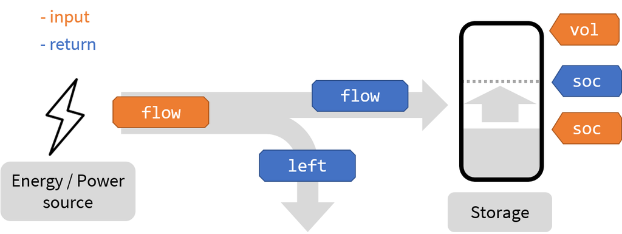

Distribute

```r
library(eflows)
distribute(flow = 50, soc = 40, vol = 80)
```

```
## $soc
## [1] 80
##
## $flow
## [1] 40
##
## $left
## [1] 10
```

The parameter `eff` reflects that not all the energy is effectively stored due to conversion loses.

```r
distribute(flow = 100, soc = 40, vol = 80, eff = 0.85)
```

```
## $soc
## [1] 80
##
## $flow
## [1] 47.05882
##
## $left
## [1] 52.94118
```

`left` is reduced when `eff` is lower than one.

The parameter `cap` expresses the technical capacity of the storage to assimilate energy in a single timestep.

```r
distribute(flow = 100, soc = 40, vol = 80, eff = 0.85, cap = 30)
```

```
## $soc
## [1] 65.5
##
## $flow
## [1] 30
##
## $left
## [1] 70
```

`flow` is limited, and `eff` causes than only part of it ends up in the `soc` of the storage.

###`distribute()` is vectorized

This means that the function can process `n` storages simultaneously, making the arguments (except `flow`) vectors of length `n`.

```r
distribute(flow = 90,
         soc = c(40, 50, 30),
         vol = c(80, 90, 70))
```

```
## $soc
## [1] 70 80 60
##
## $flow
## [1] 30 30 30
##
## $left
## [1] 0
```

The argument `share` indicates how much of the proportion of the flow shall go to each storage. It serves to indicate that some storage shall be charged faster than other.

```r
distribute(flow = 90,
         soc = c(40, 50, 30),
         vol = c(80, 90, 70),
         share = c(0.4, 0.25, 0.35))
```

```
## $soc
## [1] 76.0 72.5 61.5
##
## $flow
## [1] 36.0 22.5 31.5
##
## $left
## [1] 0
```

If `share` of one of the storages is `0`, it is served only *after* the energy flows to the rest of the storages have been resolved.

```r
distribute(flow = 90,
         soc = c(40, 50, 30),
         vol = c(80, 90, 70),
         share = c(0, 0.25, 0.35))
```

```
## $soc
## [1] 50 90 70
##
## $flow
## [1] 10 40 40
##
## $left
## [1] 0
```

The argument `level` offers finer control over the storage charging priority. *Higher levels resolve first*, and if there is some `left`, this is resolved in successive lower levels.

```r
distribute(flow = 60,
         soc = c(40, 50, 30),
         vol = c(80, 90, 70),
         level = c(3, 2, 1))
```

```
## $soc
## [1] 80 70 30
##
## $flow
## [1] 40 20  0
##
## $left
## [1] 0
```

Last, `active` especifies if the storage actually participates in the energy allocation, regardless of `share` and `level` arguments.

```r
distribute(flow = 100,
         soc = c(40, 50, 30),
         vol = c(80, 90, 70),
         share = c(0.8, 0.1, 0.1),
         level = c(3, 2, 1),
         active = c(FALSE, TRUE, TRUE))
```

```
## $soc
## [1] 40 90 70
##
## $flow
## [1]  0 40 40
##
## $left
## [1] 20
```

### Discharging

All the previous can also be applied to storage discharge. To express it, `flow` shall be negative, and `vol` shall be `0`.

```r
distribute(flow = -100, soc = c(40, 50, 30), vol = c(0, 0, 0))
```

```
## $soc
## [1]  5 15  0
##
## $flow
## [1] -35 -35 -30
##
## $left
## [1] 0
```

Note that `vol` can be any number between `0` and `soc`, so the storage can be discharged *but only up to a given point*.